# Der Effekt von Earnings-Conference Calls am Aktienmarkt

# Motivation

Earnings Conference Calls sind zentrale Informationsereignisse in Finanzmärkten. Hier kommuniziert das Management direkt mit Investoren und Analysten über die aktuelle Geschäftslage und Zukunftsaussichten. Die finanzwirtschaftliche Forschung zeigt, dass diese Calls erhebliche Kursbewegungen auslösen können - doch die zugrundeliegenden Mechanismen sind noch nicht vollständig verstanden.

Während traditionelle Finanztheorie von effizienten Märkten ausgeht, die alle verfügbaren Informationen sofort verarbeiten, zeigen empirische Studien, dass die Art der Kommunikation und das Sentiment der Aussagen eigenständige Erklärungskraft für Aktienkursreaktionen besitzen. Diese Erkenntnisse haben direkte praktische Relevanz: Banken nutzen Sentiment-Analysen für algorithmische Handelsstrategien, Hedge Fonds entwickeln systematische Ansätze zur Textauswertung, und Asset Manager integrieren qualitative Informationen in ihre Bewertungsmodelle.

In diesem Projekt kombinieren Sie Event Studies - eine etablierte Methode der empirischen Finanzforschung zur Messung von Informationseffekten - mit modernen Large Language Models zur systematischen Textanalyse. Sie untersuchen, ob und wie sich qualitative Aussagen des Managements in quantifizierbaren Marktreaktionen niederschlagen, und lernen dabei sowohl die methodischen Grundlagen der Kausalitätsidentifikation als auch den praktischen Umgang mit KI-gestützten Finanzanalysen kennen.

# Event-Study-Methodik und theoretische Diskussion

1. Lesen Sie das Kapitel [“Event Studies” in Huntington-Klein (2021)](https://theeffectbook.net/ch-EventStudies.html) und beantworten Sie die folgenden Fragen dazu:

Kann eine Eventstudie helfen, den kausalen Effekt eines Earnings Conference Calls auf die Aktienrendite eines Unternehmens zu identifizieren? Gehen Sie bei der Beantwortung dieser Frage insbesondere auf die nachfolgenden Punkte ein:

- Welche Art von Variation nutzt eine Eventstudie zur Identifikation des Effekts?
- Welche Voraussetzung(en) müssen erfüllt sein, damit die Eventstudie eine gültige Kausalschätzung liefert?
  - Was bedeutet das “Joint-Test Problem” in diesem Kontext?

**Ziele einer Eventstudien:**

Eine Eventstudie kann grundsätzlich dazu verwendet werden, den kausalen Effekt eines Earnings Conference Calls auf die Aktienrendite eines Unternehmens zu identifizieren, allerdings nur unter bestimmten Voraussetzungen. Dabei nutzt die Eventstudie die zeitliche Variation rund um das spezifische Ereignis, indem sie die Entwicklung der Aktienrendite vor und nach dem Conference Call miteinander vergleicht. Die zentrale Annahme dabei ist, dass sich die beobachtete Veränderung auf das Ereignis selbst zurückführen lässt, während alle anderen Einflussfaktoren konstant bleiben.

**Voraussetzungen für eine gültige Kausalschätzung:**

Damit eine Eventstudie tatsächlich eine gültige Kausalschätzung liefert, müssen jedoch bestimmte Voraussetzungen erfüllt sein. Erstens darf es im sogenannten „Eventfenster“, also dem Zeitraum um den ECC herum, keine anderen Ereignisse geben, die die Aktienrendite ebenfalls beeinflussen könnten. Nur wenn dies gewährleistet ist, kann eine beobachtete Veränderung der Rendite dem Conference Call zugeschrieben werden. Zweitens muss der Zeitpunkt des Calls exogen sein, also unabhängig von anderen Entwicklungen, insbesondere von vorhergehenden Kursbewegungen. Wenn der Zeitpunkt des ECC im Voraus bekannt und regelmäßig terminiert ist, wie es bei vielen börsennotierten Unternehmen der Fall ist, ist diese Bedingung meist erfüllt. Drittens wird implizit vorausgesetzt, dass die Märkte effizient sind, d. h. dass alle neuen Informationen unmittelbar in die Aktienkurse eingepreist werden. Nur dann lässt sich eine Reaktion in den Kursen genau dem Zeitpunkt des Events zuordnen.

**Das Joint-Test Problem:**

Ein zentrales methodisches Problem bei Eventstudien ist das sogenannte „Joint-Test Problem“. Dieses beschreibt, dass die Gültigkeit der Kausalschätzung auf der gemeinsamen Annahme beruht, dass das Modell für die erwartete Rendite korrekt spezifiziert ist und dass keine anderen Ereignisse gleichzeitig auftreten. Wird nach dem Event eine Abweichung zwischen der beobachteten und der erwarteten Rendite festgestellt, kann diese sowohl auf einen tatsächlichen Effekt des Conference Calls als auch auf eine fehlerhafte Modellierung des Erwartungswerts zurückzuführen sein. Da beide Annahmen gemeinsam getestet werden, lässt sich nie mit absoluter Sicherheit sagen, ob eine beobachtete Veränderung wirklich durch das Event verursacht wurde oder ob das Modell für die normale Entwicklung der Rendite fehlerhaft war.

Insgesamt lässt sich festhalten, dass Eventstudien unter bestimmten Bedingungen eine plausible Methode zur Identifikation kausaler Effekte darstellen. Bei sorgfältiger Anwendung, insbesondere bei der Auswahl des Eventfensters, der Modellierung der Normalrendite und der Berücksichtigung des Joint-Test Problems kann man Aufschluss darüber geben, ob und in welchem Umfang ein Earnings Conference Call die Aktienrendite beeinflusst.

# Daten und Datenaufbereitung

## Finanzmarktkennzahlen

2. Sie sollten in einem ersten Schritt Finanzkennzahlen aus Datastream herunterladen. Insbesondere sollten Sie den Return Index (RI) und die Total Assets (WC02999) für alle Firmen im Euro Stoxx 600 Technology Index ( wir haben Ihnen die RIC Kürzel in der Readme bereitgestellt ) vom 01.01.2020 bis heute extrahieren.

Bitte laden Sie für den Return Index tägliche Daten herunter und für die Total Assets Quartalsdaten. Weiterhin sollten Sie den Total Return Index (RI) des Euro Stoxx 600 (RIC = .STOXX) herunterladen (auch tägliche Daten). Bitte achten Sie darauf alle Daten **in Euro** herunterzuladen.

Achten Sie darauf die RIC als eindeutige Identifikationskennung in ihren Datensatz aufzunehmen.

Das Institut für Finanzwirtschaft der Universität Ulm hat einen ausführlichen [Guide zu Datastream](https://www.uni-ulm.de/fileadmin/website_uni_ulm/allgemein/Update_Introduction_Datastream_May_2025.pdf) erstellt, der Ihnen beim Download der Daten sicherlich helfen kann.

Die Universität Ulm stellt für den Download Remote-PCs zur Verfügung, auf die Sie sich von daheim aus einloggen können. Bitte buchen Sie sich hier einen Slot um Zugriff auf diese PCs zu erhalten: https://www.uni-ulm.de/mawi/iof/lehre/proposals-for-theses/datastream-and-workspace/

Sie sollten ihre Daten in Excel herunterladen und in ihrem Projekt im Unterordner `data` abspeichern.

*Hinweis 1:* Es empfiehlt sich zwei Tabellenblätter im Excel File anzulegen, eines für die täglichen Daten und eines für die Quartalsdaten

*Hinweis 2:* Datastream ist eine Datenbank, die Kennzahlen zur Finanzlage von börsennotierten Unternehmen weltweit beinhaltet. Die Lizenzen zu Datastream an der Universität Ulm werden von der Studienkommission Wirtschaftswissenschaften und der LBBW bezahlt und die Datenbank steht allen WiWi-Studierenden frei zur Verfügung. [Nähere Informationen zu Datastream finden Sie hier](https://www.uni-ulm.de/mawi/iof/lehre/proposals-for-theses/datastream-and-workspace/) (Bitte beachten: Sie müssen im Uninetz (z.B. über VPN) eingeloggt sein um die Informationen zu sehen und um sich auf die Remote-PCs loggen zu können).

*Hinweis 3:* Bei den Total Assets müssen Sie immer das Enddatum des vorherigen Jahres nehmen für den Download, d.h. Start Date wäre 31.12.2019

3. Lesen Sie die Excel Datei, welche Sie in Aufgabe 2 erstellt haben, in R ein. Achten Sie darauf, dass diese Daten tidy und richtig formatiert sind. Joinen Sie die täglichen Daten mit den Quartalsdaten für die relevanten Firmen. Die Quartalsdaten zählen für das komplette Quartal zu dem diese hinzugemerged wurden.

Setzen Sie sich mit den Aktienkursen auseinander und beantworten folgende Fragen: - Sie wollen in Aufgabe 4 *Renditen* berechnen, warum sollten Sie Daten zum “Total Return Index” und nicht dem “Price” oder “Unadjusted Price” herunterladen? Schauen Sie sich zur Klärung dieser Frage den [Guide der Uni Ulm zu Datastream](https://www.uni-ulm.de/fileadmin/website_uni_ulm/allgemein/Update_Introduction_Datastream_May_2025.pdf) genauer an. Diesen Guide sollten sie auch für den Download der Daten heranziehen.

*Hinweis:* In dem tidy Datensatz sollten Sie eine Spalte mit dem Unternehmensidentifier (RIC), eine mit dem Datum und eine mit der Variablen (RI bzw. Total Assets) haben

**Total Return Index anstelle von Price oder Unadjusted Price:**

Für die Berechnung von Renditen ist es entscheidend, den richtigen Kursindex zu verwenden. Aus diesem Grund sollte der Total Return Index (RI) bevorzugt werden, anstelle des einfachen Price Index oder des Unadjusted Price. Der Total Return Index berücksichtigt nicht nur Kursveränderungen, sondern auch Dividendenzahlungen sowie weitere Kapitalmaßnahmen wie etwa Aktiensplits oder Spin-offs. Dadurch bildet er die tatsächliche Wertentwicklung einer Aktie aus Sicht eines Investors vollständig ab.

Im Gegensatz dazu spiegelt der Price Index lediglich die reine Kursentwicklung einer Aktie wider und vernachlässigt Dividenden. Der Unadjusted Price geht sogar noch einen Schritt weiter zurück und zeigt den unveränderten Börsenkurs ohne jegliche Anpassung an Kapitalmaßnahmen – er ist daher für ökonomische Analysen ungeeignet.

Gerade bei langfristigen Analysen oder bei der Modellierung von Aktienrenditen (wie etwa im Rahmen von Regressionsanalysen oder Portfoliobewertungen) ist es daher essenziell, den Total Return Index zu verwenden. Nur so kann gewährleistet werden, dass sämtliche Ertragskomponenten eines Investments korrekt berücksichtigt werden. Dies wird auch im Datastream-Guide der Universität Ulm ausdrücklich empfohlen.

## Renditen berechnen

4. In ihrem Datastream-Datensatz, welchen Sie in Aufgabe 2 bereits eingelesen und in Aufgabe 3 bearbeitet haben, sind die *Total Return Indices* (RI) der größten Unternehmen aus der Tech-Branche in Europa enthalten, sowie der *Total Return Indix* des Euro Stoxx 600. Der Euro Stoxx 600 ist ein großer, diversifizierter Aktienindex in Europa in dem die 600 größten Unternehmen gelistet sind. Sie sollten den Euro Stoxx 600 als Benchmark ( Rendite des Marktes ) für ihre betrachteten Unternehmen verwenden. Bitte berechnen Sie in dieser Aufgabe die Tagesrenditen aller Einzelunternehmen als:

$$\begin{equation}
Rendite_{i,t} = \frac{RI_{i,t} - RI_{i,t-1}}{RI_{i,t-1}}
\end{equation}$$

mit i = {jedes Einzelunternehmen im Datensatz} und t = {Tag}

und des Euro Stoxx 600 als:

$$\begin{equation}
Rendite_{m,t} = \frac{RI_{m,t} - RI_{m,t-1}}{RI_{m,t-1}}
\end{equation}$$

mit m = {Euro Stoxx 600} und t = {Tag}

Prüfen Sie auf NA in den Anfangszeilen und entfernen Sie diese.

Speichern Sie die Renditen der jeweiligen Unternehmen in einer neuen Variable `Rendite` ab und die Rendite des Euro Stoxx 600 als `Marktrendite`.

5. In Aufgabe 1 hatten Sie sich bereits mit der Event-Study Methodik beschäftigt, welche Sie im weiteren Verlauf des Projektes anwenden sollen. Ein erster Schritt ist es, sogenannte *Abnormale Renditen* zu berechnen. Dies sollten Sie in dieser Aufgabe mit dem sogenannten Market-adjusted returns model tun. Bitte ziehen Sie dafür die Rendite des Marktindex von der Rendite des einzelnen Unternehmens pro Tag ab.

$$\begin{equation}
AbnormaleRendite_t = Rendite_{i,t} - Rendite_{m,t}
\end{equation}$$

Beantworten Sie dazu folgende Frage:

- Warum ist es nötig die Marktrendite ( $Rendite_{m,t}$ ) von der Rendite der Einzelaktien abzuziehen? Nutzen Sie ihre Erkenntnisse aus Aufgabe 1 zur Beantwortung dieser Frage.

**Rendite minus Marktrendite, warum?:**

Um den kausalen Effekt eines Earning Conference Calls auf die Aktienrendite isolieren zu können, ist es notwendig, allgemeine Markteinflüsse herauszurechnen. Das Market-Adjusted Returns Model verwendet hierfür die Marktrendite als Referenz für die erwartete Entwicklung einer Aktie an einem bestimmten Tag. Durch das Abziehen der Marktrendite von der tatsächlichen Aktienrendite ergibt sich die abnormale Rendite. Sie beschreibt jenen Teil der Kursveränderung, der nicht durch allgemeine Marktbewegungen erklärt werden kann.

Diese Adjustierung ist entscheidend, da makroökonomische Ereignisse häufig alle Aktien gleichzeitig beeinflussen. Ohne eine solche Korrektur könnte man fälschlicherweise einen Effekt dem Event zuschreiben, obwohl dieser durch den Gesamtmarkt verursacht wurde. Wie in Aufgabe 1 beschrieben, bildet die abnormale Rendite daher die Grundlage, um die kausale Wirkung des Events unter der Annahme konstanter externer Einflüsse untersuchen zu können.

## Earnings Call-Transkripte von LSEG Workspace einlesen

Die Basis für alle weiteren Analysen sind die Abnormalen Renditen der einzelner Unternehmen, die Sie in den vorherigen Aufgaben berechnet haben. Jedoch benötigen Sie nun noch ein Event, dessen Effekt Sie im Rahmen der Eventstudie analysieren möchten. Hier kommen die bereits in der Motivation erwähnten Earnings-Conference-Calls ins Spiel, die Sie im weiteren Verlauf des Projekts näher analysieren sollten. Die Earnings Conference Calls finden für große Unternehmen in der Regel quartalsweise statt. Manche Unternehmen halten jedoch auch nur halbjährliche Earnings Conference Calls ab und andere verzichten ganz darauf.

6. Wir haben Ihnen die Earnings Conference Calls aus LSEG Workspace für alle Firmen aus dem Euro Stoxx 600 Technology Sektor ab 2020 bis zum aktuellen Rand heruntergeladen und diese unter `data/transcripts.zip` bereitgestellt. Lesen Sie die Dateien in R ein. Ihr Datensatz sollte für jedes Transkript das RIC-Kürzel, Datum und den Text des Transkripts beinhalten, dies können Sie aus dem Namen der Datei extrahieren.

*Hinweis:* Das RIC Kürzel finden Sie im Namen der Datei (Beispiel: “2020-Jan-28-SAPG.DE-140242583050-Transcript.txt” -> “Datum-RIC-Nummer-Transcript.txt”)

Die Earnings Conference Calls laufen immer gleich ab: Zuerst spricht der CEO und meist CFO über die aktuellen Entwicklungen am Markt und wie das Unternehmen aktuell steht. Weiterhin werden Einschätzungen für die Zukunft angesprochen. Im zweiten Teil, der Q&A Sektion, dürfen Analysten Fragen an das Management stellen. Dieser Teil ist meist informativer als die vorbereiteten Statements des Managements, da die Fragen nicht vorher abgesprochen werden und das Management spontane Antworten bereithalten muss.

Sie sollen sich in diesem Projekt auf den zweiten Teil, d.h. die Q&A Section in den Earnings Conference Calls konzentrieren.

7. Analysieren Sie im ersten Schritt die Earnings Conference Calls indem Sie einige davon überfliegen. Schauen Sie explizit nach Hinweisen, ob und wie die Q&A Sektion im Text von den anderen Inhalten abgetrennt ist. Anschließend sollten Sie diese Q&A Sektion in den Earnings Conference Calls in R extrahieren, da Sie nur diese Sektion in den späteren Aufgaben analysieren sollen.

Da es vorteilhaft für ihre weitergehenden Analysen ist möglichst kompakte Texte ohne Redundanzen zu haben, sollten Sie zusätzlich die Definitionen und Disclaimer Sektion am Ende des Earnings Calls entfernen.

*Hinweis 1:* Der Anteil der Q&A Sektion an der Gesamtkonversation liegt in der Regel unter 80%. Für manche Earnings Conference Calls ist dieser Anteil höher, aber hier würde ich empfehlen nachzuschauen, ob Sie die Q&A Sektion richtig extrahiert haben. Manchmal gibt es keine Q&A Sektion, dann sollte dort auch kein Text extrahiert werden.

*Hinweis 2:* Nutzen Sie das Paket `stringr` um Textmanipulationen vorzunehmen. In diesem [Cheatsheet](https://rstudio.github.io/cheatsheets/strings.pdf) sehen Sie die Hauptanwendungen inkl. regulärer Ausdrücke, welche wichtig sind um mit Texten zu arbeiten.

8. Stellen Sie in einer Grafik anschaulich dar, wie viele Worte in einem typischen Earnings Conference Call verwendet werden und wie viel davon die Q&A Sektion einnimmt.

Beschreiben Sie ihre Grafik.

*Hinweis:* Eventuell wollen Sie hier die Verteilungen zeigen o.ä.? Entscheiden Sie selbst, welche Grafik Sie produzieren.

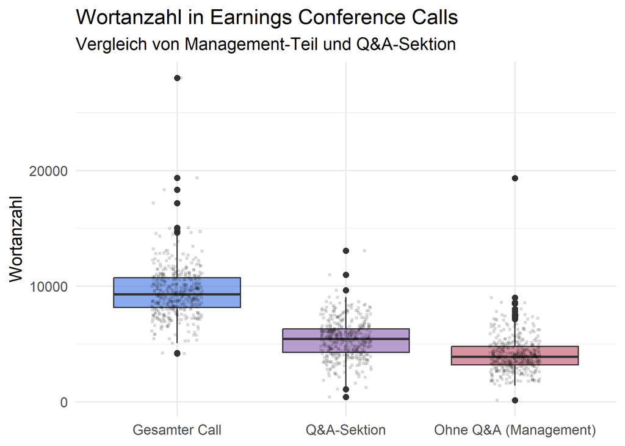

**Analyse der Wortanzahl in Earnings Conference Calls:**

Um die Struktur und den Umfang von Earnings Conference Calls im europäischen Technologiesektor zu verstehen, wurde die Wortanzahl der einzelnen Calls analysiert. Die erstellte Visualisierung zerlegt die Calls in ihre Hauptbestandteile: den vom Management vorbereiteten Präsentationsteil (“Ohne Q&A”) und die anschließende Frage-Antwort-Runde (“Q&A-Sektion”). Dies ermöglicht eine detaillierte Betrachtung der Gesamtlänge und der relativen Bedeutung der einzelnen Segmente.

Die Analyse zeigt, dass ein durchschnittlicher Earnings Conference Call eine beachtliche Länge aufweist. Im Median umfasst ein gesamter Call rund 9.500 Wörter. Die zentrale Hälfte aller untersuchten Calls bewegt sich dabei in einem Korridor von etwa 8.500 bis 11.000 Wörtern. Einzelne Ausreißer demonstrieren jedoch, dass manche Calls auch deutlich umfangreicher sein können, was auf besonders ereignisreiche Quartale oder intensive Diskussionen hindeutet.

Zusammenfassend lässt sich festhalten, dass die Q&A-Sektion nicht nur ein Anhängsel der Management-Präsentation ist, sondern den Kern eines Earnings Conference Calls bildet. Sie macht im Durchschnitt mehr als die Hälfte der gesamten Wortanzahl aus und ist entscheidend für das Gesamtbild, das ein Unternehmen vermittelt. Für weiterführende Analysen, wie etwa die der Stimmung, ist die separate Betrachtung dieses dialogorientierten Teils daher von essenzieller Bedeutung.

## Themenkategorien und Sentiment-Scores

Nachdem Sie nun die Earnings Conference Calls in R eingelesen und einen ersten Eindruck von deren Inhalt erhalten haben sollten Sie diese mit einem LLM (konkret mit Google Gemini) analysieren. Dafür sollten Sie einen Zero-Shot Prompt erstellen und mit Hilfe dieses Prompts die Aussage der Q&A Sektionen der Earnings Conference Calls analysieren.

9. Entwickeln Sie einen Zero-Shot Prompt für ein Large Language Model (LLM), der Earnings Conference Call Transcripts analysiert und strukturierte Sentiment-Bewertungen ausgibt. Bitte beachten Sie dabei folgende Punkte:

Zielkategorien:

- Unternehmensperformance (Finanzlage, Wachstumschancen, Unternehmensrisiken)
- Marktumfeld (Branche, Wettbewerb, externe Faktoren)

Output-Format:

- JSON-Struktur mit Sentiment-Scores von -1 (sehr negativ) bis +1 (sehr positiv)
- Keine zusätzlichen Erklärungen oder Markdown-Formatierung

Sie sollten in ihrem Prompt nach einem JSON Output verlangen (strukturiertes Format), welchen Sie mit dem Paket `jsonlite` gut in R verarbeiten können.

*Hinweis 1:* Im Anhang ist eine Erklärung für die Unterschiede zwischen einem Zero-Shot Prompt, einem One-Shot Prompt und einem Few-Shot Prompt

*Hinweis 2:* Wir haben Ihnen ein [Tutorial zusammengestellt](https://projektkurs-data-science-ulm2425.netlify.app/tutorials/zero-prompting), welches das Prompting an einem Beispiel zeigt.

10. Im nächsten Schritt sollten Sie sich in das Paket [`ellmer`](https://ellmer.tidyverse.org/) einarbeiten. Durch `ellmer` erhalten Sie Zugriff auf alle gängigen LLMs mittels R über einen API Zugang. Wir haben ihnen für dieses Projekt ein Google Konto pro Gruppe erstellt und den API Schlüssel für jede Gruppe in das dazugehörige Repo (Readme) gepushed.
- Lesen Sie sich in das [`ellmer`](https://ellmer.tidyverse.org/) Paket ein und wie Sie den API Schlüssel für Google Gemini in ihrer .Renviron Datei hinterlegen können
- Untersuchen Sie die unterschiedlichen Modelle, die Google zur Verfügung stellt und deren Ratelimits: https://ai.google.dev/gemini-api/docs/models?hl=de

Bitte beantworten Sie folgende Fragen:

- Was sind die Vorteile/Nachteile der einzelnen Google Modelle?
- Welches (kostenlose) Modell würden Sie für ihre aktuellen Analysen bevorzugt einsetzen? Begründen Sie!
- Welche Möglichkeiten haben Sie, nicht in die Ratelimits zu kommen?
- In `ellmer` können Sie mittels dem [`params()`](https://www.tidyverse.org/blog/2025/05/ellmer-0-2-0/#parameters) Parameter auch die Temperatur ihres Modells einstellen. Was ist mit der Temperatur gemeint und was sind die Vorteile/Nachteile einer niedrigen Temperatur?

**Vorteile und Nachteile:**

Im folgenden werden die verschiednen Google Modelle gegenüber gestellt und die jeweiligen Vor-/ und Nachteile herausgefilter.

**📊 Übersicht: Google Gemini Modelle – Vorteile & Nachteile**

*Stand: Juni 2025 – Quelle: https://ai.google.dev/gemini-api/docs/models*

| Merkmale | Gemini 2.5 Pro 👑 | Gemini 2.5 Flash 🚀 | Gemini 2.5 Flash-Lite 🪶 |
| --- | --- | --- | --- |
| Vorteile | Höchste Genauigkeit, großes Kontextfenster (1 Mio. Tokens), multimodal | Schnellstes, effizient, günstiger als Pro, gute Qualität | Schnellstes und kostengünstigstes Modell, geringe Latenz |
| Nachteile | Höhere Kosten, höhere Latenz | Weniger leistungsfähig bei komplexen Aufgaben | Noch geringere Tiefe bei komplexen Aufgaben, aktuell in Preview |
| Typische Anwendungsfälle | Komplexe Analysen, Programmierung, Forschung | Chatbots, einfache Automatisierungen, schnelle Antworten | Übersetzungen, Klassifizierungen, einfache Aufgaben |
| Kosten | Teil von Google One AI Pro (ca. 20€/Monat), auch in Gratisversion nutzbar | Günstiger als Pro, auch in Gratisversion nutzbar | Bruch der Flash-Kosten (Preview) |
| Ratelimits | Bis zu 100 Anfragen/ Tag (Pro-Abo) | Ca. 60 Anfragen/Min. (API) | Noch nicht final definiert (Preview) |

**Bevorzugtes Modell:** Für aktuelle Analysevorhaben bietet sich das Modell Gemini 2.5 Flash an, sofern es im jeweiligen Projektkontext kostenfrei verfügbar ist.

- **Kostenfreie Einstiegsebene:** Flash-Modelle zählen häufig zu den bevorzugten Varianten für kostenfreie oder ressourcenschonende Anwendungen. Sie sind besonders geeignet für Einstiegszwecke oder analytische Aufgaben mit moderatem Anspruchsniveau.
- **Hohe Reaktionsgeschwindigkeit:** Die Architektur ist auf schnelle Antwortzeiten optimiert, was besonders bei interaktiven Szenarien, Dashboards oder häufigen API-Aufrufen von Vorteil ist. Geringe Latenz fördert flüssige Workflows.
- **Großzügige Ratenlimits:** Im Vergleich zu Pro-Modellen weisen Flash-Varianten meist deutlich höhere Limits bei Anfragen pro Minute oder pro Tag auf. Dadurch lassen sich auch umfangreichere oder wiederholte Ausführungen ohne Einschränkungen realisieren.
- **Multimodale Funktionalitäten:** Trotz des ressourcenschonenden Designs bleibt die Unterstützung für multimodale Eingaben (z.B. Text und Bild) bestehen – was das Modell vielseitig einsetzbar macht.

Gemini 2.5 Flash verbindet Reaktionsgeschwindigkeit, Skalierbarkeit und Verfügbarkeit und stellt damit eine leistungsfähige Grundlage für kostenfreie analytische Anwendungen dar – ohne unnötige Komplexität oder Einschränkungen.

**Ratelimits umgehen:**

Ratenlimits sind Beschränkungen der Anzahl von Anfragen, die Sie pro Zeiteinheit an die API senden können. Um die Ratenlimits nicht zu überschreiten, können Sie folgende Strategien anwenden:

- **Drosselung (Throttling) der Anfragen:** Die wichtigste Methode besteht darin, im Code eine Wartezeit zwischen aufeinanderfolgenden API-Aufrufen zu implementieren. Liegt das Limit beispielsweise bei 60 Anfragen pro Minute, sollte nicht mehr als eine Anfrage pro Sekunde gesendet werden.
- **Batch-Verarbeitung:** Wenn möglich, mehrere kleine Anfragen zu einer größeren zusammenfassen. Müssen beispielsweise mehrere kurze Texte übersetzt werden, lohnt sich ein Blick auf eine mögliche Unterstützung von Batch-Übersetzungen durch die API, anstatt jede Anfrage einzeln zu senden.
- **Backoff-Strategie (Exponential Backoff):** Beim Auftreten einer Rate-Limit-Fehlermeldung nicht sofort erneut versuchen. Stattdessen eine exponentielle Backoff-Strategie verwenden: Nach jedem fehlgeschlagenen Versuch eine zunehmend längere Wartezeit einbauen, bevor ein erneuter Versuch gestartet wird. Das verringert die Belastung der API und ermöglicht eine Erholung des Dienstes.
- **Erhöhung des Ratenlimits:** Bei geschäftlichem Einsatz mit hohem Anfragevolumen kann es sinnvoll sein, den API-Anbieter (z.B. Google) zu kontaktieren und nach einer Erhöhung des Ratenlimits zu fragen. Dies ist oft mit zusätzlichen Kosten verbunden.

**Temperatur bei LLMs: Was bedeutet sie und wie beeinflusst sie Ausgaben?**

In Large Language Models (LLMs) wie Google Gemini bezieht sich die Temperatur (Temperature) auf einen Hyperparameter, der die Zufälligkeit oder Kreativität der generierten Ausgaben steuert. Technisch gesehen beeinflusst die Temperatur die Form der Wahrscheinlichkeitsverteilung der nächsten Token (Wörter oder Satzteile), die vom Modell ausgewählt werden.

- **Hohe Temperatur (z.B. 0.8 - 1.0 oder höher):** Macht die Wahrscheinlichkeitsverteilung “flacher”, was bedeutet, dass das Modell eine größere Vielfalt an weniger wahrscheinlichen Wörtern oder Phrasen auswählen kann. Dies führt zu kreativeren, überraschenderen und manchmal unvorhersehbareren Ausgaben.
- **Niedrige Temperatur (z.B. 0.1 - 0.3):** Macht die Wahrscheinlichkeitsverteilung “spitzer”, was bedeutet, dass das Modell dazu neigt, die wahrscheinlichsten Wörter oder Phrasen zu wählen. Dies führt zu vorhersehbareren, konservativeren und oft “sichereren” Ausgaben. Eine Temperatur von 0 würde bedeuten, dass das Modell immer das wahrscheinlichste Token wählt (deterministisches Verhalten).

**Vorteile einer niedrigen Temperatur:**

- **Konsistenz und Vorhersagbarkeit:** Die Ausgaben sind stabiler und wiederholbarer. Bei derselben Eingabe erhalten Sie mit höherer Wahrscheinlichkeit ähnliche oder identische Ausgaben.
- **Faktische Genauigkeit (tendiert dazu):** Wenn es um faktenbasierte Informationen geht, reduziert eine niedrige Temperatur die Wahrscheinlichkeit, dass das Modell “halluziniert” oder ungenaue Informationen generiert. Es bleibt näher an dem, was es als die “richtigste” Antwort gelernt hat.
- **Präzision und Spezifität:** Für Aufgaben, die präzise und auf den Punkt gebrachte Antworten erfordern (z.B. Code-Generierung, Datenextraktion, Zusammenfassungen von Fakten), ist eine niedrige Temperatur vorteilhaft.
- **Weniger Unsinn/Irrelevanz:** Die Wahrscheinlichkeit, dass das Modell thematisch abweicht oder unsinnige Sätze generiert, wird reduziert.

**Nachteile einer niedrigen Temperatur:**

- **Mangelnde Kreativität und Vielfalt:** Die generierten Texte können sich repetitiv anfühlen, klischeehaft sein oder es fehlt ihnen an originellen Ideen. Für kreative Schreibaufgaben (Geschichten, Gedichte, Marketingtexte) ist dies ein großer Nachteil.
- **Generische oder langweilige Ausgaben:** Da das Modell immer die “wahrscheinlichste” Option wählt, können die Antworten sehr generisch und unspektakulär wirken.
- **Potenziell unzureichende Exploration:** In Aufgaben, bei denen es auf verschiedene Perspektiven oder Lösungsansätze ankommt, kann eine niedrige Temperatur dazu führen, dass das Modell nur die offensichtlichsten Wege einschlägt und weniger kreative Lösungen übersieht.
- **Geringere Fehlertoleranz bei unerwarteten Eingaben:** Wenn die Eingabe etwas unklar oder mehrdeutig ist, könnte eine niedrige Temperatur dazu führen, dass das Modell eine einzige, vielleicht falsche oder unzureichende Interpretation beibehält, anstatt verschiedene Möglichkeiten zu erkunden.
11. Nutzen Sie ihren in Aufgabe 9 erstellten Prompt mit dem `ellmer` Paket und ihrem Google API-Key um alle 431 Earnings Conference Call Transkripte zu analysieren. Nutzen Sie für ihre Analyse das Modell Google Gemini 2.0-flash oder Google Gemini 2.5-flash.

Speichern Sie die Ergebnisse ihrer Analyse in einem strukturierten Tibble ab. Anschließend sollten Sie den Datensatz auch unter `data/sentiment.Rds` abspeichern.

Stellen Sie ihre Ergebnisse in einer Tabelle dar und beschreiben diese kurz:

- Wie ist der Mittelwert, Standardabweichung und Median der Einschätzung bezüglich Unternehmensperformance und Marktumfeld in ihren Earnings Conference Calls?

*Hinweis 1:* Achten Sie darauf nicht bei jedem Knitten die Analyse neu zu starten, sondern setzen Sie den Chunk dieser Aufgabe auf `eval = FALSE` und lassen Sie die Analyse nur einmal durchlaufen und speichern Sie die Ergebnisse ab (und laden diese später um damit weiterarbeiten zu können)

*Hinweis 2:* Achten Sie auf ihre Ratelimits und beanspruchen Sie den API Zugriff nicht zu stark, z.B. durch den Einbau von “sleep”-Zeiten in ihrem Code

Deskriptive Statistik der Sentiment-Variablen

|  | Mittelwert | Standardabweichung | Median |
| --- | --- | --- | --- |
| Unternehmensperformance | 0.35 | 0.23 | 0.37 |
| Marktumfeld | 0.18 | 0.26 | 0.17 |

Die Analyse der Earnings Conference Calls zeigt, dass die *Unternehmensperformance* mit einem Mittelwert von 0.35 und einem Median von 0.37 tendenziell positiv bewertet wird, wobei eine Standardabweichung von 0.23 auf eine moderate Streuung hinweist. Das *Marktumfeld* hingegen wird mit einem Mittelwert von 0.18 und einem Median von 0.17 weniger optimistisch, aber immer noch leicht positiv eingeschätzt, mit einer etwas größeren Streuung (Standardabweichung von 0.26).

Sie haben in der vorherigen Aufgabe die Stimmung bezüglich der Kategorien Unternehmensperformance und Marktperformance in den Earnings Conference Calls bestimmt. Eine Frage wäre, ob sich diese Stimmung über die Zeit hinweg verändert hat. In der folgenden Aufgabe sollen Sie sich die durchschnittliche Stimmung in diesen zwei Kategorien für die einzelnen Jahre in ihrem Datensatz näher anschauen.

12. Erstellen Sie eine geeignete Grafik um die Stimmung *aller Earnings Conference Calls eines Jahres* zu visualisieren. Tragen Sie separat die Stimmung bezüglich Unternehmensperformance und Marktumfeld ab.

Beschreiben Sie ihre Grafik.

Interpretieren Sie diese Grafik, insbesondere im Hinblick auf die gesamtwirtschaftlichen Ereignisse der letzten fünf Jahre. Hätten Sie die Ergebnisse in dieser Art erwartet?

*Hinweis:* Sie sollten sich hier eine sinnvolle Grafik überlegen, welche die Stimmungslage über die Zeit gut darstellt.

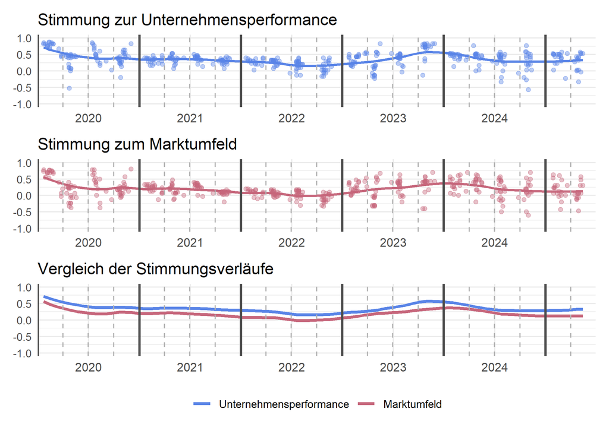

**Beschreibung:**

Die obigen Grafiken visualisieren die Entwicklung der Stimmungen hinsichtlich Unternehmensperformance und Marktumfeld mit der Zeit. Die fett hervorgehobenen Striche trennen die Jahre voneinander, während die dünneren gestrichelten Linien die einzelnen Quartale voneinander trennen. Jeder Punkt in der Grafik steht für ein Unternehmen, wobei die blauen Punkte in der oberen Grafik die Stimmung zur Unternehmensperformance abbilden und die roten Punkte in der mittleren Grafik die Stimmung zum Marktumfeld. In den beiden oberen Grafiken wurde der Stimmungsverlauf durch eine Linie angepasst, welche den durchschnittlichen Stimmungsverlauf aller Unternehmen aus Euro Stoxx 600 Technology von 2020 bis 2025 zusammenfasst. Auf den ersten Blick fällt auf, dass Google Gemini sehr optimistische Einschätzungen gegeben hat: es kommen sehr selten Stimmungen von unter -0.5 vor.

**Interpretation:**

Auffällig ist, dass der Kurvenverlauf, sowie die allgemeine Verteilung der Punkte in beiden Grafiken stark ähneln. Die Stimmungen zu Unternehmensperformance und Marktumfeld scheinen also positiv miteinander zu korrelieren, oder Google Gemini hat die Stimmungen für diese beiden Kategorien für jeden Q&A-Transcript ähnlich eingeschätzt. Anhand der untersten Grafik ist jedoch zu erkennen, dass die Unternehmensperformance im gesamten Zeitverlauf durchschnittlich positiver eingeschätzt wurde als die Marktperformance.

Eine weitere interessante Beobachtung bezieht sich auf die Streuung der Punkte innerhalb einzelner Quartale: in manchen Quartalen, wie zum Beispiel in dem ersten Quartal des Jahres 2020 und den Quartalen 1 bis 4 der Jahre 2021 und 2022, liegen die eingeschätzen Stimmungen alle nah beieinander (streuen wenig), in anderen Quartalen, wie beispielsweise die Quartale 2 bis 4 des Jahres 2020 und auch einige Quartale in den Jahren 2023 bis 2025, liegt allerdings eine starke Streunung der Stimmungen vor.

Die starke Streuung der Stimmungen in den Quartalen 2 bis 4 des Jahres 2020 und auch der allgemeine Abstieg der Kurve in diesem Zeitraum lässt sich durch den Einbruch der Corona Pandemie erklären. Aufgrund der großen Unsicherheit, trafen Unternehmen sehr unterschiedliche Einschätzungen über ihre Performance und das Marktumfeld, was sich in den von Gemini eingeschätzten Stimmungen widerspiegelt. Allgemein hat der Einbruch der Corona Pendemie jedoch die Stimmungen verringert.

Die geringe Streuung der Stimmungen in dem Jahr 2021 und der ersten Hälfte des Jahres 2022 kann dadurch erklärt werden, dass die Unternehmen sich gemeinschaftlich an die wirtschaftliche Lage in der Pandemie angepasst haben und ihre Performance und das Marktumfeld ähnlich einschätzen. In der zweiten Hälfte des Jahres 2022 liegen die Stimmungen wieder etwas weiter auseinander. Dies lässt sich möglicherweise auf den Beginn des Kriegs in der Ukraine zurückführen. Die allgemeine Stimmung aller Unternehmen sinkt in den Jahren 2021 und 2022 schwach.

Die Jahre 2023 bis 2025 sind erneut gekennzeichnet durch eine hohe Streuung der Stimmungen, da Unternehmen ihre Performance und das Marktumfeld in Zeiten der Unsicherheit unterschiedlich einschätzen. Die allgemeine Stimmung scheint in diesem Zeitraum bis Anfang 2024 zu steigen, und ab dem ersten Quartal des Jahres 2024 bis heute wieder zu sinken. Diese Senkung der Stimmungen könnte unter anderem durch hohe Zinsen, geopolitische Unsicherheiten, die Energiekrise und auch die US-Wahl erklärt werden. Insgesamt lässt sich sagen, dass sich Ergebnisse der Sentiment-Analyse durch Google Gemini durchaus zu erwarten waren.

# Eventstudie

Um zu evaluieren, ob die Earnings Conference Calls tatsächlich einen Einfluss auf die Aktienkurse der einzelnen Unternehmen hatten können Sie eine sogenannte Eventstudie durchführen, welche Sie bereits in Aufgabe 1 kennen gelernt haben. Bei einer Eventstudie betrachten Sie nur die Zeit (bei uns die Tage) unmittelbar vor oder nach einem Event. In diesem Projekt ist ein Event ein Earnings Conference Call des jeweiligen Unternehmens. Sie sollen in diesem Projekt herausfinden, wie sich über alle Unternehmen hinweg die Earnings Conference Calls auf die Aktienrenditen auswirken.

13. Verbinden Sie den Datensatz über die *Stimmung der Earnings Conference Calls (sentiment.Rds)* zu den einzelnen Unternehmen mit den *abnormalen Renditen* und speichern diesen Datensatz als `gesamtdatensatz` in R ab. Sie können das RIC-Kürzel und Datum für den Join verwenden. Sollte der Earnings Conference Call an keinem Handelstag stattgefunden haben, so joinen Sie bitte mit dem darauffolgenden Handelstag.
- Für die Tage an denen ein Earnings Conference Call stattgefunden hat sollten Sie eine Variable `event` generieren, welche an dem Tag des Calls gleich 0 ist.
- Für die Tage vor dem Earnings Conference Call (Event) sollte die Variable `event` rückwärts zählen (bis zu -5). Für alle Tage nach dem Event sollte die Variable `event` fortgeführt werden (bis +5).
- Erstellen Sie eine Variable `ar_505`, welche die *abnormalen Rendite* von Tag -5 bis +5 **fortlaufend** aufsummiert
- Erstellen Sie eine Variable `car_101`, welche die kumulierte abnormale Rendite im Zeitraum -1 bis +1 um das Event beinhaltet
- Erstellen Sie weiterhin diese sechs neuen Variablen:
  - `negativ_firm` = Wenn die Unternehmensperformance als negativ eingeschätzt wird
  - `neutral_firm` = Wenn die Unternehmensperformance als neutral eingeschätzt wird
  - `positiv_firm` = Wenn die Unternehmensperformance als positiv eingeschätzt wird
  - `negativ_market` = Wenn die Marktperformance als negativ eingeschätzt wird
  - `neutral_market` = Wenn die Marktperformance als neutral eingeschätzt wird
  - `positiv_market` = Wenn die Marktperformance als positiv eingeschätzt wird
- Erstellen Sie Dummy Variablen, die 1 sind für ein bestimmtes Jahr. Bspw. eine Dummyvariable die 2020 heißt und für alle Beobachtungen im Jahr 2020 sollte diese Variable 1 sein, 0 sonst. Tun Sie dies für alle Jahre in ihrem Datensatz

*Hinweis:* Die Funktion cumsum() könnte für diese Aufgabe hilfreich sein

14. Erstellen Sie je ein Liniendiagramm für die von ihnen betrachteten Unternehmen: Eines für die Stimmung bezüglich der Unternehmensperformance und eines bezüglich der Marktperformance.

Sie sollten in ihren Grafiken die kumulierten Renditen im Zeitraum [-5,5] Tage um einen Earnings Conference Call darstellen. - Die Variable “Event” sollte die Tage vor und nach dem Earnings Conference Call enthalten ([-5,5]) und auf der x-Achse dargestellt werden - Die Variable `ar_505` sollte die durchschnittliche kumulierte abnormale Rendite für den jeweiligen Tag auf der y-Achse abtragen (für alle Unternehmen in ihrem Datensatz) - In jeder Grafik sollten Sie eine extra Linie zeichnen für Earnings Conference Calls mit einer positiven/negativen und neutralen Stimmung und deren Einfluss auf den Aktienmarkt

Beschreiben und interpretieren Sie ihre Grafik. Gehen Sie hierbei insbesondere darauf ein, welche Erwartungen Sie auf der Basis ihrer Lektüre aus Aufgabe 1 hatten und in wie weit diese Erwartungen sich erfüllt haben.

*Hinweis:* In diesen Grafiken stellen Sie nicht jedes Event (d.h. die Auswirkungen eines jeden Earnings Conference Calls) einzeln dar, sondern gesamt für alle Earnings Conference Calls.

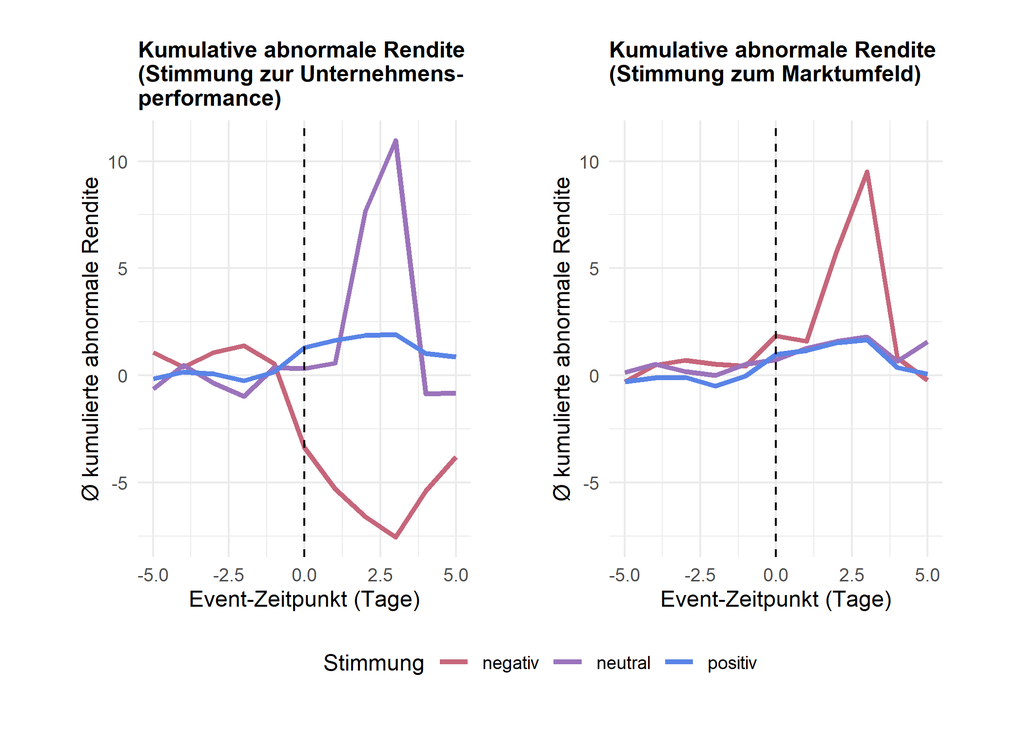

**Überblick über die dargestellten Grafiken:**

Die beiden Liniendiagramme zeigen die durchschnittliche kumulierte abnormale Rendite (CAR) im Zeitraum von fünf Tagen vor bis fünf Tage nach einem Earnings Conference Call (ECC), differenziert nach der Stimmung in der Q&A-Sektion. Die linke Grafik bezieht sich auf die Stimmung zur Unternehmensperformance, die rechte auf die Stimmung zum Marktumfeld. In beiden Fällen wird zwischen positiver (blau), neutraler (lila) und negativer (rosa) Stimmung unterschieden.

**Theoretische Erwartungen auf Basis effizienter Märkte:**

Auf Basis der theoretischen Überlegungen aus Aufgabe 1 wäre zu erwarten, dass positiv gefärbte Aussagen in den Calls zu steigenden und negativ gefärbte Aussagen zu sinkenden Aktienrenditen führen. Diese Erwartung basiert auf der Annahme effizienter Märkte, in denen neue Informationen umgehend in die Aktienkurse einfließen – vorausgesetzt, das Ereignis ist exogen und konkurrierende Events sind ausgeschlossen.

**Interpretation:**

**Bewertung vor dem Hintergrund der Event-Studien-Methodik:**

Nichtsdestotrotz bleibt das sogenannte Joint-Test-Problem bestehen: Es lässt sich nicht mit Sicherheit ausschließen, dass andere, unbeobachtete Ereignisse während des Eventfensters ebenfalls auf die Renditen gewirkt haben. Diese methodische Einschränkung begrenzt die Aussagekraft der kausalen Interpretation.

Insgesamt stützen die Ergebnisse einige theoretische Erwartungen, zeigen jedoch auch deutliche Abweichungen – insbesondere im Fall negativer Stimmung, die teilweise zu positiven Marktreaktionen führt. Dies unterstreicht die Notwendigkeit, Eventstudien kritisch zu interpretieren und die zugrunde liegenden Annahmen sorgfältig zu prüfen.

# Regressionen

Sie haben bisher den Einfluss der Earnings Conference Calls auf die Aktienrendite der größten europäischen Unternehmen im Technologie-Sektor visuell betrachtet. Im letzten Abschnitt dieser Projektarbeit analysieren Sie ihre Daten mittels linearer Regressionen.

15. In dieser Aufgabe sollten Sie zwei Regressionen erstellen:

Regressieren Sie die kumulierten abnormalen Renditen um das Event `car_101` auf die Dummyvariablen

- `negativ_firm` und `negativ_market` in der ersten Regression und
- `positiv_firm` und `positiv_market` in der zweiten Regression.

Diese Dummyvariablen geben die Stimmung in den Earnings-Conference Calls wieder.

Beschreibung und interpretieren Sie ihre Regressionsergebnisse und gehen Sie dabei auch auf folgende Fragen ein:

- Was ist die Vergleichsgruppe in den beiden Regressionen?
- Was sind die Voraussetzungen für eine kausale Interpretation der Koeffizienten. Sind diese ihrer Meinung nach gegeben?

**Regressionsergebnisse: Einfluss der Stimmung auf kumulierte abnormale Rendite (car_101)**

**Nur Beobachtungen mit event = 0**

|  | Negativ-Stimmung | Positiv-Stimmung |
| --- | --- | --- |
| Konstante | 1.419** | -0.720 |
|  | (0.521) | (1.342) |
| Negative Stimmung (Firma) | -9.849*** |  |
|  | (2.857) |  |
| Negative Stimmung (Markt) | 3.246 |  |
|  | (1.900) |  |
| Positive Stimmung (Firma) |  | 2.407 |
|  |  | (1.588) |
| Positive Stimmung (Markt) |  | -0.042 |
|  |  | (1.110) |
| R² | 0.027 | 0.006 |
| RMSE | 10.148 | 10.257 |
| Beobachtungen | 428 | 428 |

* p < 0.05, ** p < 0.01, *** p < 0.001

**Interpretation der Regressionsergebnisse:**

Die vorliegende Tabelle präsentiert die Ergebnisse von zwei separaten Regressionsmodellen: eines für “Negativ-Stimmung” und eines für “Positiv-Stimmung”, wobei jeweils nur Beobachtungen mit “event = 0” berücksichtigt wurden. Die in den Modellen verwendeten Dummyvariablen für die Stimmung beziehen sich auf die Stimmung in den Earnings-Conference Calls.

Zusammenfassend zeigen die Ergebnisse, dass eine negative Stimmung, die spezifisch dem Unternehmen zugeschrieben wird und in den Earnings-Conference Calls zum Ausdruck kommt, einen starken und signifikanten negativen Einfluss auf die kumulierte abnormale Rendite hat. Im Gegensatz dazu scheinen positive Stimmungen, sowohl auf Unternehmens- als auch auf Marktebene, sowie negative Marktstimmung in den untersuchten Modellen keinen signifikanten Einfluss auszuüben.

**Was ist die Vergleichsgruppe in den beiden Regressionen?:**

In den vorliegenden Regressionsmodellen, in denen Dummyvariablen für die Stimmung in Earnings-Conference Calls verwendet werden (implizit, da die Koeffizienten für “Negative Stimmung (Firma)”, “Negative Stimmung (Markt)”, “Positive Stimmung (Firma)” und “Positive Stimmung (Markt)” als solche interpretiert werden), ist die Vergleichsgruppe diejenige, bei der die jeweilige Stimmungskategorie nicht zutrifft.

**Was sind die Voraussetzungen für eine kausale Interpretation der Koeffizienten. Sind diese ihrer Meinung nach gegeben?:**

Um die Stimmung in Earnings-Conference Calls kausal mit der kumulierten abnormalen Rendite in Verbindung zu bringen, müssen mehrere strenge Bedingungen erfüllt sein. Zentrale Voraussetzung ist die Exogenität der Stimmungsvariablen – sie dürfen nicht von unbeobachteten Faktoren beeinflusst sein, die gleichzeitig die Rendite beeinflussen. Das ist in der Praxis schwer sicherzustellen, da etwa schlechte fundamentale Nachrichten sowohl die Stimmung als auch die Rendite negativ beeinflussen können. Auch umgekehrte Kausalität ist problematisch: Wenn der Markt bereits vor dem Call negativ reagiert, könnte dies die Stimmung der Sprecher beeinflussen. Zudem muss das Regressionsmodell alle relevanten Einflussfaktoren wie Branche, Unternehmensgröße oder parallele Nachrichtenereignisse berücksichtigen – sonst drohen Verzerrungen. Zwar ist die zeitliche Reihenfolge formal gegeben, da die Rendite nach dem Call gemessen wird, doch auch hier können Erwartungen und Marktreaktionen bereits im Vorfeld die Stimmung prägen.

**Voraussetzungen gegeben?:**

Insgesamt ist es daher unwahrscheinlich, dass alle Voraussetzungen für eine saubere kausale Interpretation erfüllt sind. Besonders die Exogenität und mögliche ausgelassene Variablen stellen große Herausforderungen dar. Die Ergebnisse zeigen zwar deutliche Zusammenhänge – insbesondere bei negativer Stimmung – sollten aber eher als Hinweise auf Korrelationen denn als Belege für Kausalität verstanden werden.

16. In ihrer deskriptiven Analyse haben Sie bereits gesehen, dass die Unternehmen, die Sie in diesem Projekt betrachten, alle unterschiedlich groß sind. Weiterhin haben Sie gesehen, dass es ein unterschiedliches Stimmungsbild in den Calls über die einzelnen Jahre hinweg gibt. Dafür möchten Sie in ihren Regressionen nun kontrollieren.
    1. Regressieren Sie die `car_101` auf die Variablen *negativ_firm* und *negativ_market* und kontrollieren Sie auf die Größe des jeweiligen Unternehmens, indem Sie die Variable *Total_Assets* in ihre Regression aufnehmen
    2. Fügen Sie in einer zweiten Analyse zusätzlich zu den Variablen aus der 1. Regression auch noch Dummyvariablen für die Jahre in dem das Event stattgefunden hat ihrer Regression hinzu.
    3. Führen Sie die Regressionen aus 1. und 2. auch für die Variablen *positiv_firm* und *positiv_market* anstatt *negativ_firm* und *negativ_market* durch, sodass Sie am Ende 4 Regressionen haben

Beschreiben und interpretieren Sie ihre Ergebnisse im Hinblick auf die Größe der Koeffizienten und deren Signifikanz. Gehen Sie insbesondere auf folgende Fragen ein:

- Warum sollte ihre Regression nicht fünf Dummyvariablen, je eine für jedes Jahr, sondern nur vier beinhalten?
- Verändert sich durch die Dummyvariablen der Koeffizient von *negativ_firm* und *negativ_market* bzw. *positiv_firm* und *positiv_market*?
- Hätten Sie eine Veränderung des Koeffizienten von *negativ_firm*, *negativ_market*, *positiv_firm* oder *positiv_market* erwartet? Begründen Sie ihre Antwort mit ihren deskriptiven Analysen.

**Regressionsergebnisse: Einfluss von Stimmung, Größe und Jahr auf kumulierte abnormale Rendite (car_101)**

**Nur Konferenztage (event == 0); abhängige Variable: car_101**

|  | Negativ Größe | Negativ Größe Jahr | Positiv Größe | Positiv Größe Jahr |
| --- | --- | --- | --- | --- |
| Konstante (Referenzjahr 2020) | 1.632* | 0.162 | -0.786 | -2.516 |
|  | (0.680) | (1.190) | (1.480) | (1.820) |
| Negative Stimmung (Firma) | -10.196*** | -10.784*** |  |  |
|  | (3.068) | (3.078) |  |  |
| Negative Stimmung (Markt) | 2.641 | 2.634 |  |  |
|  | (2.024) | (2.029) |  |  |
| Unternehmensgröße (Total Assets) | -0.000 | -0.000 | -0.000 | -0.000 |
|  | (0.000) | (0.000) | (0.000) | (0.000) |
| Jahr 2021 |  | 0.827 |  | 0.701 |
|  |  | (1.625) |  | (1.655) |
| Jahr 2022 |  | 2.313 |  | 2.713 |
|  |  | (1.618) |  | (1.685) |
| Jahr 2023 |  | 4.010* |  | 3.521* |
|  |  | (1.620) |  | (1.633) |
| Jahr 2024 |  | 0.550 |  | 0.179 |
|  |  | (1.638) |  | (1.655) |
| Jahr 2025 |  | 6.775 |  | 6.260 |
|  |  | (10.156) |  | (10.284) |
| Positive Stimmung (Firma) |  |  | 2.580 | 2.747 |
|  |  |  | (1.696) | (1.712) |
| Positive Stimmung (Markt) |  |  | 0.094 | 0.450 |
|  |  |  | (1.180) | (1.219) |
| R² | 0.031 | 0.052 | 0.009 | 0.029 |
| RMSE | 10.076 | 9.967 | 10.190 | 10.088 |
| Beobachtungen | 383 | 383 | 383 | 383 |

* p < 0.05, ** p < 0.01, *** p < 0.001

**Interpretation der Regressionsergebnisse:**

Die Tabelle präsentiert vier Regressionsmodelle, die den Einfluss von Stimmung, Unternehmensgröße und Jahr auf die kumulierte abnormale Rendite (car_101) untersuchen, basierend auf 383 Beobachtungen von Konferenztagen mit “event=0”.

Zusammenfassend zeigen die Ergebnisse, dass nur eine negative Firmenstimmung einen signifikanten und substanziellen negativen Einfluss auf die kumulierte abnormale Rendite hat. Positive Stimmungen und die Unternehmensgröße haben keinen signifikanten Effekt. Das Hinzufügen von Jahres-Dummys verbessert die Modellerklärung, und das Jahr 2023 zeigt einen signifikant positiven Effekt auf die abnormale Rendite.

**Verändert sich durch die Dummyvariablen der Koeffizient von negativ_firm und negativ_market bzw. positiv_firm und positiv_market?**

Diese Veränderungen treten auf, weil die Jahres-Dummyvariablen jahresspezifische Effekte oder Trends in der abhängigen Variable (kumulierte abnormale Rendite) erfassen, die sonst von den anderen Variablen im Modell “aufgefangen” würden. Wenn die Stimmungsvariablen (z.B. negativ_firm) über die Jahre hinweg unterschiedliche durchschnittliche Ausprägungen hatten, und diese jahresspezifischen Muster auch mit der abnormalen Rendite korrelieren, dann kann das Hinzufügen der Jahres-Dummys helfen, diese Effekte zu isolieren und so zu “saubereren” Schätzungen für die Stimmungsvariablen führen.

**Veränderung des Koeffizienten von negativ_firm, negativ_market, positiv_firm oder positiv_market?**

Ja, eine Veränderung der Koeffizienten der Stimmungs-Variablen wäre zu erwarten gewesen, insbesondere wenn die deskriptiven Analysen gezeigt hätten, dass es signifikante Unterschiede in der durchschnittlichen kumulierten abnormalen Rendite oder in der Ausprägung der Stimmungs-Variablen über die Jahre hinweg gab.

Wenn zum Beispiel aus deskriptiven Analysen hervorgeht, dass es in bestimmten Jahren (z.B. 2023, das hier signifikant ist) eine generell höhere (oder niedrigere) abnormale Rendite gab, unabhängig von der Stimmung, dann würden die Jahres-Dummys diese allgemeinen Jahres-Effekte kontrollieren. Wenn gleichzeitig die durchschnittliche Ausprägung der Stimmungs-Variablen (z.B. “Negative Stimmung (Firma)”) über die Jahre variierte, und diese Variation mit den allgemeinen Jahres-Effekten auf die Rendite korreliert ist, dann würde das Weglassen der Jahres-Dummys zu einer Verzerrung der Koeffizienten der Stimmungs-Variablen führen. Die Stimmungs-Koeffizienten würden dann versuchen, sowohl ihren eigenen Effekt als auch den unerfassten Jahres-Effekt zu erklären. Durch die Aufnahme der Jahres-Dummys werden diese spezifischen Jahres-Einflüsse “herausgerechnet”, wodurch die Schätzungen für die Stimmungsvariablen unverzerrter werden können. Das hier beobachtete signifikante Jahr 2023 stützt die Annahme, dass solche jahresspezifischen Effekte existieren und die Koeffizienten beeinflussen können.

17. Zum Abschluss sollten Sie dazu Stellung beziehen, in wie weit die Erkenntnisse aus diesem Projekt für eine Handelsstrategie genutzt werden könnten. Konkret sollten Sie erläutern ob es sinnvoll ist eine Unternehmensaktie bei einem negativem Sentiment im Earnings Conference Call automatisiert zu verkaufen.

Beziehen Sie sich in ihrer Argumentation insbesondere auf:

- Zeitliche Aspekte (Wann reagiert der Markt vs. wann liegt das Sentiment vor?)
- Methodische Limitationen Ihrer Event Study
- Unsicherheiten bei der LLM-Sentiment-Analyse

Begründen Sie jeden Kritikpunkt konkret mit Bezug auf Ihre Projektarbeit und schließen Sie mit einer realistischen Einschätzung ab: Wofür könnten Ihre Ergebnisse trotz dieser Limitationen in der Praxis dennoch wertvoll sein?

**Zeitliche Aspekte:**

Eine automatisierte Handelsstrategie, die Unternehmensaktien nach einem negativen Sentiment im Earnings Conference Call (ECC) systematisch verkauft, erscheint vor dem Hintergrund unserer Analyse nur sehr eingeschränkt sinnvoll. Dies liegt zunächst an zeitlichen Aspekten: Der Markt reagiert in der Regel unmittelbar auf neue Informationen – oftmals noch während des Calls selbst oder direkt im Anschluss. Das LLM-basierte Sentiment hingegen liegt typischerweise erst nach vollständiger Transkription und Analyse des Calls vor. Unsere Eventstudie zeigt, dass ein Großteil der Kursreaktion bereits am Event-Tag selbst eintritt. Ein auf dem LLM-Sentiment basierender Verkaufsbefehl würde daher in den meisten Fällen zeitlich zu spät kommen, um von abnormalen Renditen zu profitieren.

**Methodische Limitaionen der Event Study:**

Auch wenn wir mit dem risk-adjusted returns model versucht haben, die erwartete Rendite auf Basis historischer Zusammenhänge mit dem Markt besser zu modellieren, bleibt die grundlegende Schwäche bestehen: Die Identifikation eines kausalen Effekts ist nur unter sehr restriktiven Annahmen möglich. So darf der ECC nicht von anderen kursrelevanten Ereignissen überlagert werden, und der Zeitpunkt des Calls muss exogen sein. Zudem muss das Modell der Normalrendite korrekt spezifiziert sein. In der Praxis ist jedoch kaum sichergestellt, dass all diese Bedingungen erfüllt sind. Eine beobachtete Renditeabweichung könnte daher ebenso gut auf ein Modellierungsproblem wie auf den tatsächlichen Inhalt des Calls zurückgehen (Joint-Test-Problem). Für eine automatisierte Strategie ist diese Unsicherheit kritisch.

**Unsicherheiten bei der LLM-Sentiment-Analyse:**

Darüber hinaus ist auch das LLM-Sentiment mit Unsicherheiten behaftet. Die Interpretation eines Transkripts durch ein Sprachmodell hängt stark vom Prompt, der Modellarchitektur und der Trainingsbasis ab. Während unsere Methode eine systematische und skalierbare Analyse ermöglicht, ist nicht garantiert, dass das Modell die für Anleger:innen entscheidenden Aussagen richtig gewichtet oder den tatsächlichen Ton des Calls adäquat erfasst. Zudem reagiert der Markt häufig nicht auf die Gesamtstimmung eines Calls, sondern auf einzelne kritische Aussagen – etwa zur Prognose oder zum Ausblick –, die möglicherweise vom Modell nicht ausreichend berücksichtigt werden. Somit besteht das Risiko, dass das Modell ein „negatives Sentiment“ erkennt, obwohl der Markt aufgrund anderer Inhalte des Calls positiv reagiert (oder umgekehrt).

Trotz dieser Einschränkungen können unsere Ergebnisse durchaus praktischen Nutzen entfalten. So bietet die Kombination aus Eventstudie und Sentimentanalyse ein nützliches Werkzeug, um rückblickend systematische Zusammenhänge zwischen Aussagen in Earnings Calls und Marktreaktionen zu untersuchen. Auch kann sie als unterstützende Komponente im Investment-Research dienen – etwa zur Priorisierung von Calls, die vertieft analysiert werden sollten. Für eine vollautomatisierte Handelsstrategie auf Basis des LLM-Sentiments reicht die Präzision und Reaktionsgeschwindigkeit der Methode jedoch derzeit nicht aus. Realistisch betrachtet liegt der Mehrwert unserer Analyse eher in der ergänzenden Einordnung und im Überblick als in der konkreten Handelsempfehlung.

# Zusatzaufgabe

In Aufgabe 6 berechnen Sie die *abnormalen Renditen* der einzelnen von ihnen betrachteten Unternehmen. Nun könnte es allerdings sein, dass es nicht ausreicht den Marktindex einfach von der Aktienrendite abzuziehen um für die erwartete Performance der Aktie zu kontrollieren. Potentiell wäre es besser für die durchschnittliche Performance der Aktie zu kontrollieren in der keine Events stattfinden.

Sie können eine solche durchschnittliche Performance schätzen. Dazu sollten Sie eine Schätzperiode *vor* dem Event definieren. Diese Periode sollen Sie auf 120 bis 10 Handelstage vor dem Event festlegen. Die durchschnittliche Rendite der Einzelaktie sollten Sie in dieser Periode auf die Marktrendite regressieren. Dieses Modell wird `Risk-adjusted returns model` in Huntington-Klein (2021) genannt:

$$\begin{equation}
\hat{Rendite}_{i,t} = \alpha + \beta Rendite_{m,t}
\end{equation}$$

Anschließend nutzen Sie die vorhergesagten Werte und ziehen diese in der Eventphase von der Rendite der Einzelaktie ab.

18. Erstellen Sie die kumulierten abnormalen Renditen im Zeitraum -5 bis +5 mit Hilfe ihres Risk-adjusted returns model neu (und nennen diese `mar_505`). Erstellen Sie die kumulierten abnormalen Renditen im Zeitraum -1 bis +1 um das Event mit Hilfe ihres Risk-adjusted returns model neu (und nennen die Variable `cmar_101`) und vergleichen die Werte in einer geeigneten Grafik mit den Ergebnissen aus dem market-adjusted returns model (`car_101`).
- Gibt es hier große Unterschiede?
- Warum gibt es diese Unterschiede, oder warum sehen Sie nur geringe Unterschiede?

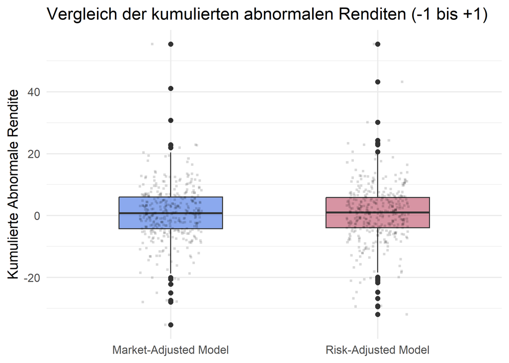

**Vergleich Abnormaler Renditen: Geringe Unterschiede mit validen Gründen**

Die Gegenüberstellung der kumulierten abnormalen Renditen im Event-Fenster von Tag -1 bis +1, welche sowohl mittels des Market-Adjusted Model als auch des Risk-Adjusted Model berechnet wurden, offenbart visuell lediglich geringe bis moderate Unterschiede. Beide Modellansätze zeigen Boxplots mit sehr ähnlichen Medianen, die um null zentriert sind, sowie stark überlappenden Interquartilsbereichen und einer vergleichbaren Streuung der einzelnen Beobachtungen. Während extremere Ausreißer in beiden Verteilungen auftreten, bleiben die Kernbereiche der jeweiligen Verteilungen nahezu identisch.

Diese geringen Differenzen sind aus mehreren Gründen erwartbar und lassen sich durch die unterschiedliche Modellierung der erwarteten Normalrendite begründen. Das Market-Adjusted Model ist der einfachere Ansatz, der davon ausgeht, dass die erwartete Rendite einer Aktie schlicht der Marktrendite entspricht. Im Gegensatz dazu ist das Risk-Adjusted Model präziser, da es die erwartete Rendite mittels einer Regression schätzt, die sowohl das individuelle Beta (die Sensitivität der Aktie zum Markt) als auch das Alpha (eine konstante, nicht-marktspezifische Über- oder Unterperformance) der Aktie berücksichtigt.

Die Ähnlichkeit der Ergebnisse lässt sich durch verschiedene Faktoren erklären. Es ist plausibel, dass die geschätzten Beta-Werte der untersuchten Unternehmen im Schätzzeitraum nahe bei 1 lagen, was die Korrektur durch Beta nur gering ausfallen lässt. Ebenso deutet die geringe Differenz darauf hin, dass die Alpha-Werte – die die historische nicht-marktspezifische Performance abbilden – im Schätzzeitraum oftmals nahe null waren. Darüber hinaus spielt das sehr kurze Event-Fenster von lediglich drei Handelstagen eine Rolle; in solch komprimierten Zeiträumen dominieren meist die direkten Effekte des Ereignisses die Kursbewegungen, wodurch die feineren Anpassungen durch Alpha und Beta, die sich über längere Perioden stärker kumulieren würden, weniger ins Gewicht fallen. Schließlich ist die hohe Korrelation der Einzelaktienrenditen mit den Marktrenditen ein fundamentaler Aspekt: Da ein Großteil der Aktienrenditen bereits durch die allgemeine Marktbewegung erklärt wird, tragen die zusätzlichen Erklärungsbeiträge von Alpha und Beta nicht zu einer drastisch abweichenden, sondern lediglich zu einer Verfeinerung der anormalen Renditeberechnung bei.

Zusammenfassend lässt sich festhalten, dass das Risk-Adjusted Model zwar theoretisch fundierter ist, da es Risiko und spezifische Performance umfassender berücksichtigt, die praktische Anwendung in diesem spezifischen Kontext jedoch zeigt, dass die Ergebnisse beider Modelle aufgrund der genannten Faktoren sehr ähnlich sind.

19. Erstellen Sie die Grafik von Aufgabe 12 neu.

Beschreiben und interpretieren Sie ihre Grafik. Gehen Sie auch auf folgende Fragen ein:

- Könnte es zu Problemen führen, wenn in der Schätzperiode vor dem Event ein weiterer Earnings-Conference Call enthalten ist?
  - Warum könnte dies ein Problem sein, oder warum nicht?

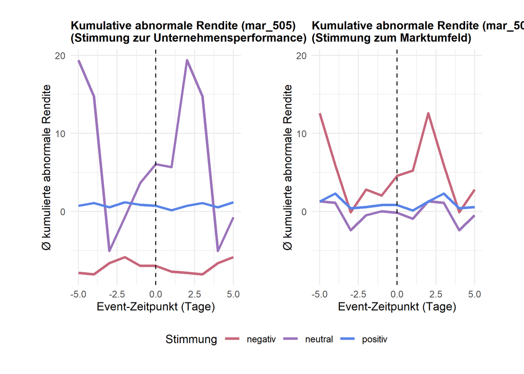

**Beschreibung und Interpretation der durchschnittlichen Stimmungen:**

Die dargestellte Grafik zeigt die Entwicklung der durchschnittlichen kumulierten abnormalen Renditen (mar_505) im Zeitraum von fünf Handelstagen vor bis fünf Handelstage nach Earnings Conference Calls (ECCs). Dabei wird unterschieden zwischen der Stimmung zur Unternehmensperformance (linke Grafik) und zur allgemeinen Marktlage (rechte Grafik). Die Stimmungen sind jeweils in „positiv“, „neutral“ und „negativ“ unterteilt.

Die rechte Grafik zur Stimmung gegenüber dem Marktumfeld zeigt ein weniger eindeutiges Bild. Überraschenderweise erzielt hier die Gruppe mit negativer Markteinschätzung die höchsten durchschnittlichen abnormalen Renditen im Zeitraum nach dem Event. Diese gegenläufige Entwicklung lässt sich nicht direkt mit marktpsychologischen Erwartungen erklären. Es könnte sich um eine Fehleinordnung der Stimmung, eine begrenzte Datenlage oder einen anderweitigen verzerrenden Effekt handeln. Die Gruppen mit positiver und neutraler Markteinschätzung zeigen keine nennenswerten Bewegungen und verlaufen weitgehend horizontal um die Nulllinie.

**Auswirkungen mehrerer Earnings Conference Calls in der Schätzperiode vor einem Event:**

Das Vorhandensein eines weiteren Earnings Conference Calls (ECC) in der Schätzperiode vor einem bestimmten Event könnte zu Problemen führen, aber auch unter bestimmten Umständen unbedenklich sein, abhängig von der Forschungsfrage und der Methodik.

Ein wesentliches Problem könnte die Verwässerung oder Überlappung von Informationen sein. Wenn das Ziel der Analyse darin besteht, die singuläre Auswirkung eines spezifischen ECC auf ein Event zu isolieren, würde ein weiterer ECC in der Schätzperiode vor dem Event die saubere Messung dieser isolierten Wirkung erschweren. Die Sentiment-Daten des zusätzlichen ECC würden in die Schätzung der “normalen” oder erwarteten Stimmung vor dem Event einfließen. Wenn nun das Event selbst die Folge eines bestimmten ECC ist, wäre es schwierig zu bestimmen, welcher der beiden ECCs oder ob eine Kombination beider für die beobachtete Stimmung verantwortlich ist. Dies würde die Kausalität verwischen und die Validität der Ergebnisse beeinträchtigen, insbesondere wenn die beiden ECCs relativ nahe beieinander liegen und sich ihre Inhalte überschneiden oder gegenseitig beeinflussen. Die Annahme, dass die Schätzperiode eine Basislinie ohne den Einfluss des zu untersuchenden Events darstellt, wäre nicht mehr haltbar.

Andererseits könnte es kein Problem darstellen oder sogar vorteilhaft sein, wenn die Forschungsfrage darauf abzielt, die kumulative Wirkung oder den allgemeinen Informationsfluss in einer bestimmten Periode zu erfassen. Wenn beispielsweise das Interesse nicht darin besteht, den Effekt eines einzelnen ECCs zu messen, sondern die aggregierte Stimmung, die Investoren vor einem bestimmten Event erreicht, dann wäre die Einbeziehung mehrerer ECCs in der Schätzperiode sogar wünschenswert. In diesem Fall würde die Schätzperiode die gesamte relevante Kommunikationslandschaft eines Unternehmens vor dem Event abbilden. Dies wäre besonders relevant, wenn Unternehmen regelmäßig Berichte veröffentlichen oder wenn es darum geht, die Gesamtstimmungstendenz über einen längeren Zeitraum vor einem bedeutenden Ereignis zu analysieren. Die Annahme hier wäre, dass alle ECCs innerhalb der Schätzperiode Teil des erwarteten Informationsflusses sind und somit in die Baseline-Stimmung einfließen sollten, um die Abweichung durch das nachfolgende Event präziser zu messen.

20. Lesen Sie das Kapitel [“Fixed Effects” in Huntington-Klein (2021)](https://theeffectbook.net/ch-FixedEffects.html#how-does-it-work), speziell Kapitel 16.1
21. Regressieren Sie die `cmar_101` auf die Variablen *negativ_firm* und *negativ_market* und kontrollieren Sie auf die Größe des jeweiligen Unternehmens, indem Sie die Variable *Total_Assets* in ihre Regression aufnehmen. Kontrollieren Sie weiterhin auf das Jahr in dem das Event stattgefunden hat. Fügen Sie weiterhin der Regression Firmen-Fixe Effekte hinzu.

Beschreiben und interpretieren Sie ihre Ergebnisse.

Gehen Sie zusätzlich auf die folgenden Frage ein:

- Was sind Firmen-Fixe Effekte und warum könnten diese für ihre Regression sinnvoll sein?

*Hinweis:* Mit dem [Paket `fixest`](https://cran.r-project.org/web/packages/fixest/vignettes/fixest_walkthrough.html) und der Funktion feols() können Sie einfach ihren Regressionen fixe Effekte hinzufügen

**Regression: Einfluss negativer Sentiments auf kumulierte abnormale Renditen (cmar_101)**

**Abhängige Variable: cmar_101**

|  | Ohne Fixed Effects | Mit Firmeneffekten |
| --- | --- | --- |
| Konstante | -0.003 |  |
|  | (0.019) |  |
| Negative Stimmung (Firma) | 0.003 | 0.002 |
|  | (0.004) | (0.004) |
| Negative Stimmung (Markt) | 0.002 | 0.001 |
|  | (0.004) | (0.004) |
| Unternehmensgröße (log Total Assets) | -0.000 | -0.000 |
|  | (0.001) | (0.002) |
| EventYear2021 | 0.006 |  |
|  | (0.003) |  |
| EventYear2022 | 0.002 |  |
|  | (0.003) |  |
| EventYear2023 | 0.007* |  |
|  | (0.003) |  |
| EventYear2024 | -0.000 |  |
|  | (0.003) |  |
| EventYear2025 | 0.009* |  |
|  | (0.004) |  |
| R² | 0.026 | 0.094 |
| RMSE | 0.021 | 0.020 |
| Beobachtungen | 416 | 416 |

* p < 0.05, ** p < 0.01, *** p < 0.001

**Interpretation der Regressionsergebnisse:**

Die vorliegende Tabelle zeigt die Ergebnisse von zwei Regressionsmodellen, die den Einfluss negativer Stimmungen auf die kumulierte abnormale Rendite (cmar_101) untersuchen. Beide Modelle basieren auf 416 Beobachtungen. Das erste Modell wurde “Ohne Fixed Effects” geschätzt, während das zweite “Mit Firmeneffekten” schätzt.

**Modell “Ohne Fixed Effects”:** In diesem Modell ist die Konstante mit −0.003 und einem Standardfehler von 0.019 nicht statistisch signifikant. Dies deutet darauf hin, dass die durchschnittliche kumulierte abnormale Rendite in Abwesenheit der spezifischen Stimmungen und anderer Kontrollelemente nicht signifikant von Null abweicht. Die zentralen Variablen, “Negative Stimmung (Firma)” und “Negative Stimmung (Markt)”, zeigen Koeffizienten von 0.003 bzw. 0.002. Beide sind sehr klein und, wie durch ihre Standardfehler von 0.004 indiziert, nicht statistisch signifikant. Dies legt nahe, dass in diesem Modell, ohne die Berücksichtigung von Firmeneffekten, weder eine negative Firmenstimmung noch eine negative Marktstimmung einen messbaren Einfluss auf die kumulierte abnormale Rendite haben. Die “Unternehmensgröße (log Total Assets)” weist einen Koeffizienten von −0.000 auf und ist ebenfalls nicht signifikant, was bedeutet, dass die Unternehmensgröße in diesem Modell keinen Erklärungsbeitrag leistet. Von den “EventYear”-Dummyvariablen sind “EventYear2023” mit einem Koeffizienten von 0.007 und “EventYear2025” mit einem Koeffizienten von 0.009 auf dem 0.05-Niveau signifikant (p<0.05). Dies bedeutet, dass die kumulierte abnormale Rendite in diesen Jahren signifikant höher war als im Referenzjahr (vermutlich 2020, da die anderen Jahre als Dummies aufgeführt sind). Die R² dieses Modells beträgt 0.026, was bedeutet, dass 2.6% der Varianz in der abhängigen Variable durch die einbezogenen Prädiktoren erklärt werden. Der RMSE liegt bei 0.021.

**Modell “Mit Firmeneffekten”:** Dieses Modell beinhaltet zusätzlich Firmeneffekte, was typischerweise durch Dummyvariablen für jede Firma oder durch eine Within-Transformation geschieht, um unbeobachtete, firmenspezifische Heterogenität zu kontrollieren. Im Gegensatz zum ersten Modell kann hier keine Konstante ausgewiesen werden, da Firmeneffekte die Konstante “absorbieren”. Die Koeffizienten für “Negative Stimmung (Firma)” (0.002) und “Negative Stimmung (Markt)” (0.001) bleiben extrem klein und nicht signifikant, selbst nach der Kontrolle für Firmeneffekte. Auch die “Unternehmensgröße (log Total Assets)” zeigt weiterhin keinen signifikanten Einfluss (Koeffizient −0.000). Bemerkenswert ist, dass in diesem Modell die Jahres-Dummyvariablen nicht mehr aufgeführt sind, da sie wahrscheinlich durch die Firmeneffekte ebenfalls absorbiert würden, wenn die Jahresvariationen konsistent über die Firmen sind oder die Firmeneffekte einen Großteil der jahresspezifischen Variationen abfangen. Die R² dieses Modells steigt erheblich auf 0.094, was darauf hindeutet, dass die Firmeneffekte einen substanziellen Teil der Varianz in der kumulierten abnormalen Rendite erklären, der ohne diese Effekte unberücksichtigt bliebe. Der RMSE sinkt leicht auf 0.020.

Zusammenfassend lässt sich sagen, dass in beiden Modellen die negativen Stimmungen (weder firmen- noch marktbezogen) keinen signifikanten Einfluss auf die kumulierte abnormale Rendite zu haben scheinen. Auch die Unternehmensgröße ist nicht signifikant. Im Modell ohne Firmeneffekte zeigen die Jahre 2023 und 2025 einen signifikant positiven Effekt. Die Einführung von Firmeneffekten im zweiten Modell erhöht die erklärte Varianz (R²) erheblich, was auf eine wichtige Rolle unbeobachteter firmenspezifischer Charakteristika für die abnormale Rendite hindeutet. Trotzdem bleibt der Einfluss der negativen Stimmungen auch nach Kontrolle dieser Effekte insignifikant, was im Widerspruch zu der vorherigen Analyse mit car_101 stehen könnte und auf die spezifische Natur von cmar_101 hindeuten mag.

**Was sind Firmen-Fixe Effekte:**

Ein sogenannter „firmen-fixer Effekt“ in einer Regression ist eine statistische Technik, die es erlaubt, für alle zeitlich konstanten Merkmale einer Firma zu kontrollieren – selbst wenn diese Merkmale nicht direkt beobachtbar oder messbar sind. Anstatt sich mit der Messung jeder einzelnen unbeobachteten Einflussgröße zu beschäftigen, wird jede Firma als eigene Kategorie betrachtet, die ihre individuellen, über die Zeit konstanten Eigenschaften repräsentiert. Dazu zählen zum Beispiel Aspekte wie die Unternehmenskultur, die Gründungszeit, der Ruf oder grundlegende Managementprinzipien.

**Warum könnten diese für ihre Regression sinnvoll sein?:**

Der Einsatz von Firmen-Fixen Effekten ist besonders dann sinnvoll, wenn man den Fokus auf Veränderungen innerhalb einer Firma über die Zeit legen möchte, ohne durch Unterschiede zwischen Firmen – sogenannte „between variation“ – abgelenkt zu werden. Denn diese Methode eliminiert alle systematischen Unterschiede zwischen Firmen und konzentriert sich ausschließlich auf die „innerhalb-Variation“. Das bedeutet, die Analyse untersucht, wie sich z.B. Produktivität innerhalb einer Firma verändert, wenn sich eine erklärende Variable (wie Investitionshöhe) verändert – unabhängig davon, wie produktiv andere Firmen im Vergleich sind.

Ein weiterer Vorteil liegt in der Schließung potenzieller „Backdoor-Pfade“ zwischen unabhängigen und abhängigen Variablen, die durch konstant bleibende, unbeobachtete Firmenmerkmale entstehen könnten. Fixe Effekte integrieren diese Konstanz direkt in die Modellstruktur, entweder durch die Aufnahme von Dummy-Variablen für jede Firma oder durch die sogenannte „demeaning“-Methode, bei der Variablen vom firmenbezogenen Mittelwert bereinigt werden.

Die Interpretation der Regressionskoeffizienten erfolgt dann auf Basis dieser bereinigten Werte: Ein positiver Koeffizient zeigt, dass ein über dem firmentypischen Durchschnitt liegender Wert der erklärenden Variable mit einem entsprechenden Anstieg der Zielgröße innerhalb derselben Firma verbunden ist.

Kurzum: Firmen-Fixe Effekte sind ein wirkungsvolles Instrument, wenn man in der Analyse unbeobachtete, firmeninterne Einflussgrößen kontrollieren und dabei möglichst saubere kausale Zusammenhänge innerhalb von Firmen identifizieren möchte.

# Literatur

- Kapitel Event Studies im Buch [The Effect Book: Event Studies](https://theeffectbook.net/ch-EventStudies.html)
- Kapitel Fixe Effekte im Buch [The Effect Book: Event Studies](https://theeffectbook.net/ch-FixedEffects.html)
- [Paket `fixest`](https://cran.r-project.org/web/packages/fixest/vignettes/fixest_walkthrough.html)

# Anhang

## Prompt Arten

Prompt-Arten unterscheiden sich in der Anzahl der Beispiele, die Sie dem KI-Modell geben:

**Zero-Shot Prompt**

- Keine Beispiele gegeben
- Nur die Aufgabe wird beschrieben
- Beispiel: “Übersetze ins Englische: Guten Morgen”

**One-Shot Prompt**

- Ein einziges Beispiel wird gezeigt
- Das Modell lernt aus diesem einen Beispiel
- Beispiel: “Übersetze ins Englische:

Guten Tag → Good day Guten Morgen → ?”

**Few-Shot Prompt**

- Mehrere Beispiele werden gegeben (typisch 2-5)
- Das Modell kann aus mehreren Mustern lernen
- Beispiel: “Übersetze ins Englische:

Guten Tag → Good day Auf Wiedersehen → Goodbye Danke → Thank you Guten Morgen → ?”